# Classification methods for Brain-Computer Interface EEG data

Livio Finos, Marco Congedo

2018-12-05

# Introduction

## Data Example

Available on https://zenodo.org/record/1494240#.XARcSGhKg2x

In the Brain Invaders P300 paradigm, a repetition is composed of 12 flashes, of which 2 include the Target symbol (Target flashes) and 10 do not (non-Target flash). For this experiment, in the Training phases the number of flashes is fixed (80 Target flashes and 400 non-Target flashes). In the Online phases the number of Target and non-Target still are in a ratio 1/5, however their number is variable because the Brain Invaders works with a fixed number of game levels, however the number of repetitions needed to destroy the target (hence to proceed to the next level) depends on the user’s performance.

In any case, since the classes are unbalanced, an appropriate score must be used for quantifying the performance of classification methods (e.g., balanced accuracy, AUC methods, etc).

Data used: Subject 11

- filename: ‘3.gdf’ experimental_condition: nonadaptive type: training
- filename: ‘4.gdf’ experimental_condition: nonadaptive type: online

```r
rm(list=ls())
# library(readr)
# train <- read_delim("C:/Users/livio/Downloads/sub11_s3_epocs.txt", delim = "\t", escape_double = FALSE, trim_ws = TRUE)
# train$X18=NULL
# # View(train)
# # table(train$X1)
# # plot(train$X1[(1:700)*1000],type="l")
#
#
# test <- read_delim("C:/Users/livio/Downloads/sub11_s4_epocs.txt", delim = "\t", escape_double = FALSE, trim_ws = TRUE)
# # View(test)
# # table(test$X1)
# test$X18=NULL
#
# # check che i tempi coincidano:
# all(unique(test$X1)==unique(train$X1))
#
# timepoints=unique(train$X1)
# ntimepoints=length(timepoints)
#
# test=test[,-1,]
# dim(test)
# train=train[,-1]
#
# test=as.matrix(test)
# train=as.matrix(train)
#
# # rashape datasets as 3D array
# train2=array(train,c(ntimepoints,nrow(train)/ntimepoints,ncol(train)))
# train2=aperm(train2,c(1,3,2))
# test2=array(test,c(ntimepoints,nrow(test)/ntimepoints,ncol(test)))
# test2=aperm(test2,c(1,3,2))
#
# save(test2,timepoints,ntimepoints,file="test2.Rdata")
# save(train2,timepoints,ntimepoints,file="train2.Rdata")

load(file="test2.Rdata")
load(file="train2.Rdata")
```

Eventi:

```r
library(readr)
eventi_s3 <- read_table2("C:/Users/livio/Dropbox (DPSS)/didattica/neuroQ/7_BCI/eventi_s3.csv")
# View(eventi_s3)
eventi_s4 <- read_table2("C:/Users/livio/Dropbox (DPSS)/didattica/neuroQ/7_BCI/eventi_s4.csv")
# View(eventi_s4)

#rename and reorder the lables
eventi_s3$type=factor(eventi_s3$type)
levels(eventi_s3$type)=c("Target","NonTarget")
eventi_s3$type=factor(eventi_s3$type,levels = c("NonTarget","Target"))

eventi_s4$type=factor(eventi_s4$type)
levels(eventi_s4$type)=c("Target","NonTarget")
eventi_s4$type=factor(eventi_s4$type,levels = c("NonTarget","Target"))

table(eventi_s3$type)
```

```
##
## NonTarget    Target
##       400        80
```

```r
table(eventi_s4$type)
```

```
##
## NonTarget    Target
##       190        38
```

## Means

```r
Mtrain_target=apply(train2[,,eventi_s3$type=="Target"],c(1,2),mean)
Mtrain_nontarget=apply(train2[,,eventi_s3$type=="NonTarget"],c(1,2),mean)

dim(Mtrain_target)
```

```
## [1] 1536   16
```

```r
dim(Mtrain_nontarget)
```

```
## [1] 1536   16
```

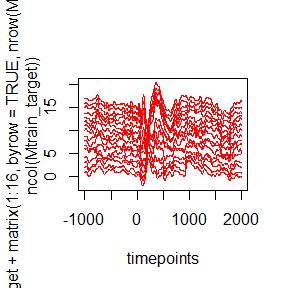

```r
matplot(timepoints,Mtrain_target+matrix(1:16,byrow = TRUE,nrow(Mtrain_target),ncol(Mtrain_target)),type="l",lty=1,col=2)
```

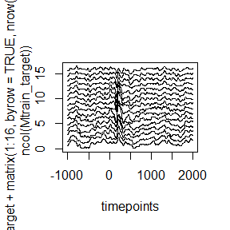

```r
matplot(timepoints,Mtrain_nontarget+matrix(1:16,byrow = TRUE,nrow(Mtrain_target),ncol(Mtrain_target)),type="l",lty=1,col=1)
```

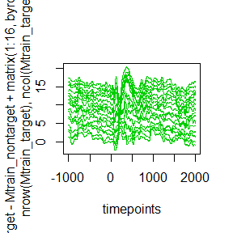

```r
matplot(timepoints,Mtrain_target-Mtrain_nontarget+matrix(1:16,byrow = TRUE,nrow(Mtrain_target),ncol(Mtrain_target)),type="l",lty=1,col=3)
```

## Select 0 to 650 ms

```r
selct_timepnts=which((timepoints>0)&(timepoints<650))

Mtrain_nontarget=Mtrain_nontarget[selct_timepnts,]
Mtrain_target=Mtrain_target[selct_timepnts,]

test2=test2[selct_timepnts,,]
```

## Euclidean distance

```r
dist_frobenius <- function(x,y){
  sqrt(sum((x-y)^2))
}

dist_frobenius(test2[,,1],Mtrain_nontarget)
```

```
## [1] 1177.565
```

```r
# dist from nontarget - dist target.
# positive score means closer to target
diff_dist=sapply(1:dim(test2)[3],function(i)
  dist_frobenius(test2[,,i],Mtrain_nontarget)-dist_frobenius(test2[,,i],Mtrain_target))

plot(diff_dist,eventi_s4$type)

table(hat_target=diff_dist>=0,True_target=eventi_s4$type)
```

```
##           True_target
## hat_target NonTarget Target
##      FALSE       141     13
##      TRUE         49     25
```

```r
eventi_s4$estimate=diff_dist>=0
eventi_s4$estimate=factor(eventi_s4$estimate)
levels(eventi_s4$estimate)=levels(eventi_s4$type)

library(caret)
```

```r
#Confusion Matrix
mat <- confusionMatrix(eventi_s4$estimate, eventi_s4$type, positive="Target")
#Confusion matrix
mat$table
```

```
##            Reference
## Prediction  NonTarget Target
##   NonTarget       141     13
##   Target           49     25
```

```r
# Sensitivity = TP/(TP+FN)
mat$byClass["Sensitivity"]
```

```
## Sensitivity
##   0.6578947
```

```r
# Specificity = TN/(TN+FP)
mat$byClass["Specificity"]
```

```
## Specificity
##   0.7421053
```

```r
mat$overall["Accuracy"]
```

```
##  Accuracy
## 0.7280702
```

```r
library(pROC)
```

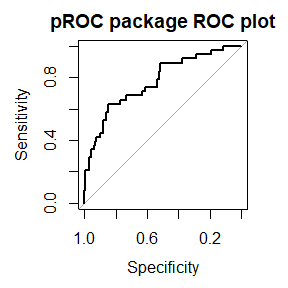

```r
roc.val <- roc(type~diff_dist, eventi_s4)
plot(roc.val, main="pROC package ROC plot")
```

```r
roc.val$auc
```

```
## Area under the curve: 0.7752
```

## Riemann

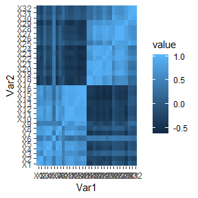

```r
# NON Target:
XNT=data.frame(cbind(test2[,,6],Mtrain_nontarget))

library(reshape2)
melted_cormat <- melt(cor(XNT))
library(ggplot2)
ggplot(data = melted_cormat, aes(x=Var1, y=Var2, fill=value)) +
  geom_tile()
```

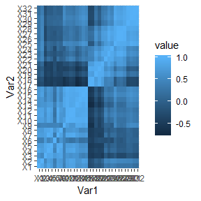

```r
# Target:
XT=data.frame(cbind(test2[,,6],Mtrain_target))

library(reshape2)
melted_cormat <- melt(cor(XT))
library(ggplot2)
ggplot(data = melted_cormat, aes(x=Var1, y=Var2, fill=value)) +
  geom_tile()
```

```r
eventi_s4$type[6]
```

```
## [1] Target
## Levels: NonTarget Target
```

```r
library(Riemann)
dist_Riemann(cor(test2[,,1]),cor(Mtrain_nontarget))
```

```
## [1] 21.92785
## attr(,"small_eigenvalues")
## [1] 0
```

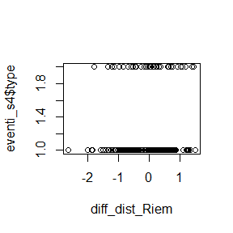

```r
# dist from nontarget - dist target.
# positive score means closer to target
diff_dist_Riem=sapply(1:dim(test2)[3],function(i)
  dist_Riemann(cor(test2[,,i]),cor(Mtrain_nontarget))-dist_Riemann(cor(test2[,,i]),cor(Mtrain_target)))

plot(diff_dist_Riem,eventi_s4$type)
```

```r
eventi_s4$estimate=diff_dist_Riem>=0
eventi_s4$estimate=factor(eventi_s4$estimate)
levels(eventi_s4$estimate)=levels(eventi_s4$type)

library(caret)
#Confusion Matrix
mat <- confusionMatrix(eventi_s4$estimate, eventi_s4$type, positive="Target")
#Confusion matrix
mat$table
```

```
##            Reference
## Prediction  NonTarget Target
##   NonTarget        96     17
##   Target           94     21
```

```r
# Sensitivity = TP/(TP+FN)
mat$byClass["Sensitivity"]
```

```
## Sensitivity
##   0.5526316
```

```r
# Specificity = TN/(TN+FP)
mat$byClass["Specificity"]
```

```
## Specificity
##   0.5052632
```

```r
mat$overall["Accuracy"]
```

```
##  Accuracy
## 0.5131579
```

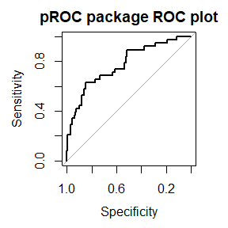

```r
library(pROC)
roc.val <- roc(type~diff_dist, eventi_s4)
plot(roc.val, main="pROC package ROC plot")
```

```r
roc.val$auc
```

```
## Area under the curve: 0.7752
```